# Correlation analysis

```r
summary(df)
```

```
 Wuchtvers_anz   MD1_ANLIEF_MG    MD2_ANLIEF_G         R_SH
 Min.   :0.000   Min.   : 0.00   Min.   :  0.00   Min.   :0.0000000
 1st Qu.:2.000   1st Qu.: 9.08   1st Qu.: 68.25   1st Qu.:0.0002800
 Median :2.000   Median :14.93   Median :166.00   Median :0.0003800
 Mean   :2.558   Mean   :16.14   Mean   :165.97   Mean   :0.0003916
 3rd Qu.:3.000   3rd Qu.:21.73   3rd Qu.:263.00   3rd Qu.:0.0004900
 Max.   :6.000   Max.   :69.87   Max.   :360.00   Max.   :0.0023100
```

Visualize and checking distribution before normalize dataset The first one feature is: **R_SH**

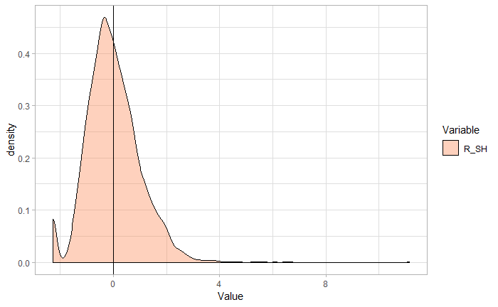

The next one feature is: **Wuchtvers_anz**

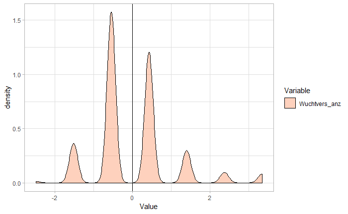

The next one feature is: **MD1_ANLIEF_MG**

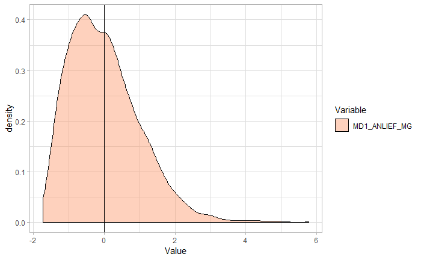

The next one feature is: **MD2_ANLIEF_G**

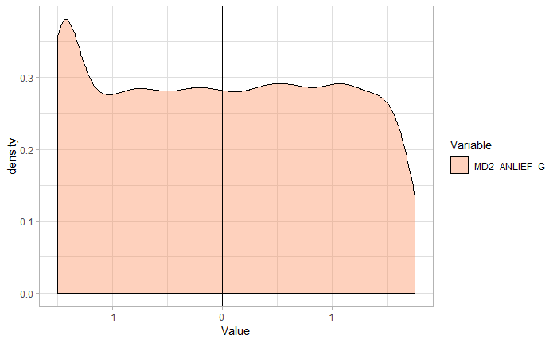

A small p-value (typically ≤ 0.05) indicates strong evidence against the null hypothesis, so you reject the null hypothesis.

A large p-value (> 0.05) indicates weak evidence against the null hypothesis, so you fail to reject the null hypothesis.

p-values very close to the cutoff (0.05) are considered to be marginal (could go either way). Always report the p-value so your readers can draw their own conclusions.

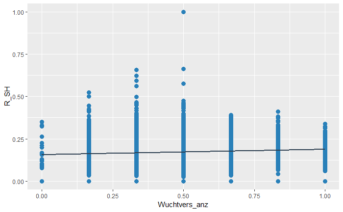

```r
ggplot(z_df, aes(x=Wuchtvers_anz, y=R_SH)) +
     geom_point(color='#2980B9', size = 3) +
    geom_smooth(method=lm, se=FALSE, fullrange=TRUE, color='#2C3E50')
```

DEnsity - We frequently encounter the situation where we would like to understand how a particular variable is distributed in a dataset.

Linear approach **1. Finds the best parametric model to fit your data. It is hard to describe a model (which must describe all possible data points) without using a parametric distribution.** **But for a model, each data point falls around the function that describes the model. In fact, the data points are distributed around the function (as you know).** **Likelihood describes the chance that a given model caused the observation that has come to pass. It reasons from observation to model. For this reason, likelihood is sometimes called inverse probability. Although likelihood and probability both deal with chances they behave differently mathematically. Most notably, the probability of disjoint events must sum to one. Not so for likelihoods.**

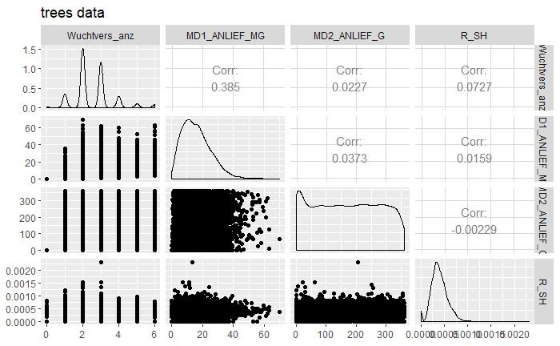

```r
ggpairs(data=df, columns=1:4, title="trees data")
```

```r
ggpairs(data=z_schaft, columns=3:7, title="trees data")
```

[output not shown]

```r
gam_mod <- gam(Final_2 ~ s(Wuchtvers_anz, k=1), data = z_schaft)
```

```
basis dimension, k, increased to minimum possible
```

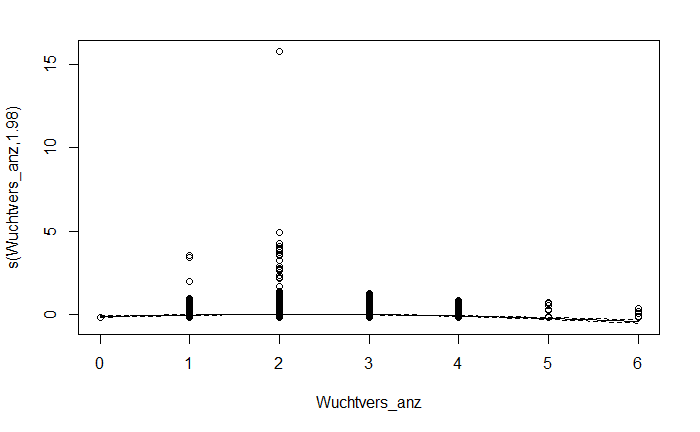

```r
plot(gam_mod, residuals = TRUE, pch = 1)
```

```r
gam_mod <- gam(Final_2 ~ s(Wuchtvers_anz, k=1), data = z_schaft)
plot(gam_mod, residuals = TRUE, pch = 1)
```

[output not shown]

```r
gam_mod <- gam(Wuchtvers_anz ~ s(Final_1), data = z_schaft)
plot(gam_mod, residuals = TRUE, pch = 1)
```

[output not shown]

```r
ggpairs(data=df, columns=1:3, title="trees data")
```

[output not shown]